# Portfolio of Companies

Abdeali Arsiwala

2024-05-17

```r
file_path <- "Earnings Quality Signals Analytics Project Data.xlsx"
financial_data <- read_excel(file_path, sheet = "Financial Statement Data")
head(financial_data)
```

| GVKEY | PERMNO | Company Name | Ticker | Fiscal Year | Current Assets | Current Liabilities | Total Assets | Cash | Debt in Current Liabilities | Long Term Debt | Inventory | Intangibles | Income Before Extraordinary Items | PP&E (Gross) | PP&E (Net) | Retained Earnings | Receivables (Total) | Depreciation and Amortization | Net Income | Operating Income After Depreciation | Operating Income Before Depreciation | Sales | Interest Expense | Income Taxes Payable | Income Taxes Total | Special Items |
| --- | --- | --- | --- | --- | --- | --- | --- | --- | --- | --- | --- | --- | --- | --- | --- | --- | --- | --- | --- | --- | --- | --- | --- | --- | --- | --- |
| 1004 | 54594 | AAR CORP | AIR | 2021 | 1007.2 | 348.2 | 1573.9 | 53.5 | 11.1 | 156.30000000000001 | 604.1 | 141.9 | 78.5 | 607.5 | 349.2 | 800.8 | 290.3 | 33.1 | 78.7 | 116.2 | 149.30000000000001 | 1817.1 | NA | 0 | 26.6 | NA |
| 1004 | 54594 | AAR CORP | AIR | 2022 | 1097.9000000000001 | 351.5 | 1833.1 | 68.400000000000006 | 12.3 | 317.89999999999998 | 624.70000000000005 | 279.10000000000002 | 89.8 | 636.70000000000005 | 367.9 | 887.1 | 335 | 27.9 | 90.2 | 151.4 | 179.3 | 1990.6 | NA | 0 | 31.4 | NA |
| 1004 | 54594 | AAR CORP | AIR | 2020 | 937 | 336.8 | 1539.7 | 51.8 | 11.5 | 193.6 | 591 | 148.80000000000001 | 46.3 | 640.29999999999995 | 380.1 | 723.4 | 238.6 | 36.299999999999997 | 35.799999999999997 | 65.5 | 101.8 | 1651.4 | NA | 0.7 | 18.2 | NA |
| 1045 | 21020 | AMERICAN AIRLINES GROUP INC | AAL | 2020 | 11095 | 16569 | 62008 | 245 | 4448 | 36573 | 1614 | 6120 | -8885 | 56495 | 39738 | -13767 | 1342 | 2365 | -8885 | -11387 | -9022 | 17337 | NA | 0 | -2568 | NA |
| 1045 | 21020 | AMERICAN AIRLINES GROUP INC | AAL | 2023 | 13572 | 22062 | 63058 | 578 | 4941 | 35722 | 2400 | 6142 | 822 | 60800 | 38703 | -12583 | 2026 | 2254 | 822 | 4013 | 6267 | 52788 | NA | 0 | 299 | NA |
| 1045 | 21020 | AMERICAN AIRLINES GROUP INC | AAL | 2021 | 17336 | 19006 | 66467 | 273 | 3996 | 42181 | 1795 | 6079 | -1993 | 55558 | 37387 | -14580 | 1505 | 2335 | -1993 | -5514 | -3179 | 29882 | NA | 0 | -555 | NA |

# Filter the data to create dataframes of companies that have both 2020 and 2021 data and remove duplicates

```r
# Filter financial data for 2020 and 2021
financial_data_2020 <- financial_data %>% filter(`Fiscal Year` == 2020)
financial_data_2021 <- financial_data %>% filter(`Fiscal Year` == 2021)

# Identify companies with financial data for both 2020 and 2021
common_permnos <- intersect(financial_data_2020$PERMNO, financial_data_2021$PERMNO)

# Filter the financial data for these companies
financial_data_2020 <- financial_data_2020 %>% filter(PERMNO %in% common_permnos)
financial_data_2021 <- financial_data_2021 %>% filter(PERMNO %in% common_permnos)

# Remove duplicates by keeping the first occurrence
financial_data_2020 <- financial_data_2020 %>%
  distinct(PERMNO, .keep_all = TRUE)

financial_data_2021 <- financial_data_2021 %>%
  distinct(PERMNO, .keep_all = TRUE)

# Verify dimensions
dim(financial_data_2020)
```

```
## [1] 7328   27
```

```r
dim(financial_data_2021)
```

```
## [1] 7328   27
```

# Merge and Clean Dataframe

```r
# Merge the 2020 and 2021 financial data
financial_data_merged <- merge(financial_data_2021, financial_data_2020, by = c("GVKEY", "PERMNO", "Company Name", "Ticker"), suffixes = c("_2021", "_2020"))

financial_data_merged <- financial_data_merged %>%
  select(-`Fiscal Year_2020`, -`Fiscal Year_2021`)

cols_to_convert <- setdiff(names(financial_data_merged), c("Company Name", "Ticker"))

financial_data_merged[cols_to_convert] <- lapply(financial_data_merged[cols_to_convert], as.numeric)

# Check the head of the merged dataframe
head(financial_data_merged)
```

|  | GVKEY | PERMNO | Company Name | Ticker | Current Assets_2021 | Current Liabilities_2021 | Total Assets_2021 | Cash_2021 | Debt in Current Liabilities_2021 | Long Term Debt_2021 | Inventory_2021 | Intangibles_2021 | Income Before Extraordinary Items_2021 | PP&E (Gross)_2021 | PP&E (Net)_2021 | Retained Earnings_2021 | Receivables (Total)_2021 | Depreciation and Amortization_2021 | Net Income_2021 | Operating Income After Depreciation_2021 | Operating Income Before Depreciation_2021 | Sales_2021 | Interest Expense_2021 | Income Taxes Payable_2021 | Income Taxes Total_2021 | Special Items_2021 | Current Assets_2020 | Current Liabilities_2020 | Total Assets_2020 | … |
| --- | --- | --- | --- | --- | --- | --- | --- | --- | --- | --- | --- | --- | --- | --- | --- | --- | --- | --- | --- | --- | --- | --- | --- | --- | --- | --- | --- | --- | --- | --- |
| 1 | 10000 | 39220 | STANDARD MOTOR PRODS | SMP | 711.205 | 476.369 | 1197.961 | 21.755 | 138.959 | 31.227 | 468.755 | 237.886 | 99.353 | 371.043 | 143.255 | 524.150 | 180.604 | 27.243 | 90.886 | 131.095 | 158.338 | 1298.816 | NA | 0.000 | 31.044 | NA | 598.536 | 302.602 | 956.540 | … |
| 2 | 10008 | 43481 | STANDEX INTERNATIONAL CORP | SXI | 374.366 | 143.709 | 962.223 | 136.367 | 7.933 | 228.531 | 91.862 | 376.983 | 38.543 | 321.655 | 170.649 | 736.349 | 137.646 | 31.000 | 36.473 | 78.198 | 109.198 | 656.232 | NA | 7.236 | 14.157 | NA | 331.997 | 122.877 | 930.878 | … |
| 3 | 10016 | 43350 | STANLEY BLACK & DECKER INC | SWK | 8526.400 | 8767.400 | 28180.000 | 142.300 | 2361.300 | 4681.200 | 5446.800 | 13483.700 | 1600.300 | 5442.300 | 2780.400 | 6896.800 | 1560.800 | 516.600 | 1689.200 | 2012.600 | 2529.200 | 15617.200 | NA | 320.400 | 61.400 | NA | 6036.000 | 4558.300 | 23566.300 | … |
| 4 | 100243 | 18724 | AMCOR PLC | AMCR | 5266.000 | 4345.000 | 17188.000 | NA | 199.000 | 6648.000 | 1991.000 | 7254.000 | 939.000 | 8045.000 | 4293.000 | -314.000 | 1864.000 | 571.000 | 939.000 | 1340.000 | 1911.000 | 12861.000 | NA | NA | 261.000 | NA | 4534.700 | 3973.600 | 16442.100 | … |
| 5 | 10030 | 18438 | STARRETT (L.S.) CO -CL A | SCX | 119.220 | 51.689 | 184.486 | 9.105 | 17.609 | 8.744 | 60.572 | 5.903 | 15.533 | 142.558 | 40.290 | 19.919 | 35.076 | 6.292 | 15.533 | 17.026 | 23.318 | 219.644 | NA | 0.000 | 1.893 | NA | 104.098 | 27.834 | 172.683 | … |
| 6 | 100338 | 81046 | RELX PLC | RELX | 3191.614 | 5075.167 | 18765.118 | 153.013 | 314.151 | 8036.584 | 47.394 | 14448.246 | 1991.881 | 1142.860 | 395.397 | NA | 2226.141 | 980.368 | 1991.881 | 2499.669 | 3480.037 | 9809.100 | NA | 259.987 | 441.437 | NA | 3053.527 | 5873.407 | 18993.906 | … |

# STEP 1 -> Calculate the Accrual Component for 2021

```r
# Calculate changes (deltas) for required components
financial_data_merged <- financial_data_merged %>%
  mutate(
    delta_CA = `Current Assets_2021` - `Current Assets_2020`,
    delta_Cash = `Cash_2021` - `Cash_2020`,
    delta_CL = `Current Liabilities_2021` - `Current Liabilities_2020`,
    delta_STD = `Debt in Current Liabilities_2021` - `Debt in Current Liabilities_2020`,
    delta_TP = `Income Taxes Payable_2021` - `Income Taxes Payable_2020`,
    Avg_Total_Assets = (`Total Assets_2020` + `Total Assets_2021`) / 2

  )

# Calculate the Accrual Component
financial_data_merged <- financial_data_merged %>%
  mutate(
    Accrual_Component_2021 = (delta_CA - delta_Cash) - (delta_CL - delta_STD - delta_TP) - `Depreciation and Amortization_2021`
  )

# Calculate the Cash Component
financial_data_merged <- financial_data_merged %>%
  mutate(
    Cash_Component_2021 = `Operating Income After Depreciation_2021` - Accrual_Component_2021  + `Depreciation and Amortization_2021`
  )

dim(financial_data_merged)
```

```
## [1] 7244   56
```

```r
# Drop rows with NA values in the Accrual_Component column
financial_data_merged <- financial_data_merged %>%
  filter(!is.na(Accrual_Component_2021) & !is.na(Cash_Component_2021) & !is.na(Avg_Total_Assets))

dim(financial_data_merged)
```

```
## [1] 3566   56
```

# STEP 2 -> Standardize the Accrual Component

```r
# Standardize the Accrual Component
financial_data_merged <- financial_data_merged %>%
  mutate(
    Per_Asset_Accrual_2021 = Accrual_Component_2021 / Avg_Total_Assets,
    Per_Asset_Cash_2021 = Cash_Component_2021 / Avg_Total_Assets,
    Per_Asset_Operating_2021 = `Operating Income After Depreciation_2021` / Avg_Total_Assets
  )

financial_data_merged <- financial_data_merged[,c(1:4, 57:59)]

dim(financial_data_merged)
```

```
## [1] 3566    7
```

```r
head(financial_data_merged)
```

|  | GVKEY | PERMNO | Company Name | Ticker | Per_Asset_Accrual_2021 | Per_Asset_Cash_2021 | Per_Asset_Operating_2021 |
| --- | --- | --- | --- | --- | --- | --- | --- |
| 1 | 10000 | 39220 | STANDARD MOTOR PRODS | SMP | 0.027381746 | 0.11960171 | 0.12169407 |
| 2 | 10008 | 43481 | STANDEX INTERNATIONAL CORP | SXI | -0.028837341 | 0.14420150 | 0.08261366 |
| 3 | 10016 | 43350 | STANLEY BLACK & DECKER INC | SWK | 0.050392009 | 0.04736184 | 0.07778720 |
| 4 | 10030 | 18438 | STARRETT (L.S.) CO -CL A | SCX | 0.002799795 | 0.12777145 | 0.09533862 |
| 5 | 100338 | 81046 | RELX PLC | RELX | -0.044608092 | 0.22893685 | 0.13240114 |
| 6 | 1004 | 54594 | AAR CORP | AIR | 0.014709661 | 0.08119219 | 0.07464029 |

# Calculate Size-Adjusted Cumulative Abnormal Returns

```r
company_stock_returns <- read_excel(file_path, sheet = "Company Stock Returns", col_names = TRUE)
size_matched_returns <- read_excel(file_path, sheet = "Size-matched Stock Returns", col_names = TRUE)

# Specify column names
column_names <- c("PERMNO", "Company Name", "Ticker",
                      "Jan_2020", "Feb_2020", "Mar_2020", "Apr_2020",
                      "May_2020", "Jun_2020", "Jul_2020", "Aug_2020",
                      "Sep_2020", "Oct_2020", "Nov_2020", "Dec_2020",
                      "Jan_2021", "Feb_2021", "Mar_2021", "Apr_2021",
                      "May_2021", "Jun_2021", "Jul_2021", "Aug_2021",
                      "Sep_2021", "Oct_2021", "Nov_2021", "Dec_2021",
                      "Jan_2022", "Feb_2022", "Mar_2022", "Apr_2022",
                      "May_2022", "Jun_2022", "Jul_2022", "Aug_2022",
                      "Sep_2022", "Oct_2022", "Nov_2022", "Dec_2022",
                      "Jan_2023", "Feb_2023", "Mar_2023", "Apr_2023",
                      "May_2023", "Jun_2023", "Jul_2023", "Aug_2023",
                      "Sep_2023", "Oct_2023", "Nov_2023", "Dec_2023")

# Set column names
colnames(company_stock_returns) <- column_names
colnames(size_matched_returns) <- column_names

head(company_stock_returns)
```

| PERMNO | Company Name | Ticker | Jan_2020 | Feb_2020 | Mar_2020 | Apr_2020 | May_2020 | Jun_2020 | Jul_2020 | Aug_2020 | Sep_2020 | Oct_2020 | Nov_2020 | Dec_2020 | Jan_2021 | Feb_2021 | Mar_2021 | Apr_2021 | May_2021 | Jun_2021 | Jul_2021 | Aug_2021 | Sep_2021 | Oct_2021 | Nov_2021 | Dec_2021 | Jan_2022 | Feb_2022 | Mar_2022 | … |
| --- | --- | --- | --- | --- | --- | --- | --- | --- | --- | --- | --- | --- | --- | --- | --- | --- | --- | --- | --- | --- | --- | --- | --- | --- | --- | --- | --- | --- | --- | --- |
| 10026 | J & J SNACK FOODS CORP | JJSF | -0.10001599999999999 | -3.0269999999999998E-2 | -0.244031 | 4.9834999999999997E-2 | 1.2596E-2 | -7.1910000000000003E-3 | -3.1463999999999999E-2 | 0.104118 | -3.6667999999999999E-2 | 3.9726999999999998E-2 | 7.2434999999999999E-2 | 7.2597999999999996E-2 | -1.7441999999999999E-2 | 3.9958E-2 | -7.2750000000000002E-3 | 4.8271000000000001E-2 | 6.6642000000000007E-2 | -3.058E-3 | -5.7507999999999997E-2 | -3.7720000000000002E-3 | -6.2939999999999996E-2 | -3.4485000000000002E-2 | -7.4347999999999997E-2 | 0.16117300000000001 | -3.9694E-2 | 7.9307000000000002E-2 | -4.8785000000000002E-2 | … |
| 10028 | ENVELA CORP | ELA | 0.60740700000000003 | 0.22580600000000001 | -5.2631999999999998E-2 | 0.44841300000000001 | -1.6438000000000001E-2 | 0.69916400000000001 | -0.30655700000000002 | -8.2741999999999996E-2 | 0.10567 | -5.8275E-2 | 0.143564 | 0.12554100000000001 | 0.203846 | -0.16134200000000001 | -4.3810000000000002E-2 | -0.22709199999999999 | 0.103093 | 0.12149500000000001 | -7.9167000000000001E-2 | -4.2986000000000003E-2 | -1.6549000000000001E-2 | 5.0480999999999998E-2 | -6.8650000000000003E-2 | 0 | -2.4570000000000002E-2 | 5.0377999999999999E-2 | 0.117506 | … |
| 10032 | PLEXUS CORP | PLXS | -7.5643000000000002E-2 | -6.7070000000000005E-2 | -0.17769399999999999 | 0.14901 | 2.4406000000000001E-2 | 9.8723000000000005E-2 | 5.2863E-2 | 2.3959999999999999E-2 | -7.1512999999999993E-2 | -1.5433000000000001E-2 | 7.4345999999999995E-2 | 4.6848000000000001E-2 | -1.6494000000000002E-2 | 9.1784000000000004E-2 | 9.3593999999999997E-2 | 6.5329999999999997E-3 | 6.8909999999999999E-2 | -7.4890999999999999E-2 | -1.1924000000000001E-2 | 1.6718E-2 | -2.6353000000000001E-2 | -2.3376000000000001E-2 | -3.6417999999999999E-2 | 0.13964799999999999 | -0.19157399999999999 | 5.0955E-2 | 4.1729999999999996E-3 | … |
| 10044 | ROCKY MOUNTAIN CHOC FACT INC | RMCF | -9.8591999999999999E-2 | -6.4904000000000003E-2 | -0.37336799999999998 | -5.2082999999999997E-2 | -5.7142999999999999E-2 | -9.3240000000000007E-3 | -0.21882399999999999 | -1.8072000000000001E-2 | -0.17791399999999999 | 0 | 0.59328400000000003 | -5.1521999999999998E-2 | 7.1605000000000002E-2 | 0.21889400000000001 | -3.7810000000000001E-3 | 0.148008 | 3.4710999999999999E-2 | 0.21884999999999999 | 9.9607000000000001E-2 | -5.4827000000000001E-2 | -6.6835000000000006E-2 | 0.17702699999999999 | -2.4109999999999999E-2 | -7.6470999999999997E-2 | 7.8980000000000005E-3 | -7.8359999999999992E-3 | -3.8217000000000001E-2 | … |
| 10051 | HANGER INC | HNGR | -0.115176 | -5.5669000000000003E-2 | -0.32466400000000001 | 0.17843400000000001 | 0 | -9.8039000000000001E-2 | 5.4348E-2 | 0.13173000000000001 | -0.19939299999999999 | 0.104298 | 0.29879800000000001 | -3.0851E-2 | -6.8212999999999996E-2 | 7.2718000000000005E-2 | 3.8217000000000001E-2 | 9.2463000000000004E-2 | 3.6101000000000001E-2 | -2.1292999999999999E-2 | -2.9271999999999999E-2 | -2.6894999999999999E-2 | -8.0402000000000001E-2 | -0.14936199999999999 | -9.6894999999999995E-2 | 7.4689000000000005E-2 | 0 | -5.5099999999999995E-4 | 1.1589E-2 | … |
| 10065 | ADAMS DIVERSIFIED EQUITY FD | ADX | 5.7070000000000003E-3 | -9.0163999999999994E-2 | -0.12447800000000001 | 0.125496 | 4.3754000000000001E-2 | 1.1533E-2 | 5.1643000000000001E-2 | 7.8444E-2 | -3.8552999999999997E-2 | -4.0099000000000003E-2 | 0.12853500000000001 | 3.6570999999999999E-2 | -8.6759999999999997E-3 | 2.8004999999999999E-2 | 3.8089999999999999E-2 | 5.1478999999999997E-2 | 7.2919999999999999E-3 | 2.4882999999999999E-2 | 1.6185999999999999E-2 | 3.7830000000000003E-2 | -4.8077000000000002E-2 | 7.1211999999999998E-2 | 2.2630999999999998E-2 | 2.9162E-2 | -4.9973999999999998E-2 | -2.9284000000000001E-2 | 3.3052999999999999E-2 | … |

```r
# Select the necessary columns for calculation
required_columns <- c("PERMNO", "Company Name", "Ticker",
                      "May_2022", "Jun_2022", "Jul_2022", "Aug_2022",
                      "Sep_2022", "Oct_2022", "Nov_2022", "Dec_2022",
                      "Jan_2023", "Feb_2023", "Mar_2023", "Apr_2023")

company_stock_returns <- company_stock_returns[, required_columns]
size_matched_returns <- size_matched_returns[, required_columns]


# Merge the two datasets
merged_returns <- merge(company_stock_returns, size_matched_returns, by = c("PERMNO", "Company Name", "Ticker"), suffixes = c("_Individual", "_Size_Matched"))

dim(merged_returns)
```

```
## [1] 2772   27
```

```r
# Remove duplicates by keeping the first occurrence
merged_returns <- merged_returns %>%
  distinct(PERMNO, .keep_all = TRUE)

dim(merged_returns)
```

```
## [1] 2772   27
```

```r
# Convert columns to numeric
cols_to_convert <- setdiff(names(merged_returns), c("Company Name", "Ticker"))
merged_returns[cols_to_convert] <- lapply(merged_returns[cols_to_convert], as.numeric)

# Drop NA values except for "Company Name" and "Ticker"
merged_returns <- merged_returns %>%
  drop_na(-`Company Name`, -`Ticker`)

# Display the result
dim(merged_returns)
```

```
## [1] 2414   27
```

```r
head(merged_returns)
```

|  | PERMNO | Company Name | Ticker | May_2022_Individual | Jun_2022_Individual | Jul_2022_Individual | Aug_2022_Individual | Sep_2022_Individual | Oct_2022_Individual | Nov_2022_Individual | Dec_2022_Individual | Jan_2023_Individual | Feb_2023_Individual | Mar_2023_Individual | Apr_2023_Individual | May_2022_Size_Matched | Jun_2022_Size_Matched | Jul_2022_Size_Matched | Aug_2022_Size_Matched | Sep_2022_Size_Matched | Oct_2022_Size_Matched | Nov_2022_Size_Matched | Dec_2022_Size_Matched | Jan_2023_Size_Matched | Feb_2023_Size_Matched | Mar_2023_Size_Matched | Apr_2023_Size_Matched |
| --- | --- | --- | --- | --- | --- | --- | --- | --- | --- | --- | --- | --- | --- | --- | --- | --- | --- | --- | --- | --- | --- | --- | --- | --- | --- | --- | --- |
| 1 | 10026 | J & J SNACK FOODS CORP | JJSF | -0.143487 | 0.094159 | -0.029715 | 0.099771 | -0.126552 | 0.140110 | 0.111171 | -0.082978 | -0.042816 | -0.014585 | 0.054600 | 0.033599 | 0.000192 | -0.089837 | 0.104552 | -0.024837 | -0.101475 | 0.105514 | 0.028266 | -0.066140 | 0.117691 | -0.025771 | -0.038080 | -0.019263 |
| 2 | 10032 | PLEXUS CORP | PLXS | 0.045107 | -0.074293 | 0.196815 | -0.002342 | -0.065827 | 0.123801 | 0.120122 | -0.066141 | -0.067425 | -0.001042 | 0.017520 | -0.103515 | 0.000192 | -0.089837 | 0.104552 | -0.024837 | -0.101475 | 0.105514 | 0.028266 | -0.066140 | 0.117691 | -0.025771 | -0.038080 | -0.019263 |
| 3 | 10104 | ORACLE CORP | ORCL | -0.020164 | -0.028504 | 0.118649 | -0.047405 | -0.176399 | 0.283609 | 0.063533 | -0.015537 | 0.086127 | -0.011983 | 0.063158 | 0.023676 | -0.002698 | -0.083900 | 0.092283 | -0.038849 | -0.091623 | 0.077099 | 0.054175 | -0.059064 | 0.067214 | -0.024233 | 0.034277 | 0.012616 |
| 4 | 10107 | MICROSOFT CORP | MSFT | -0.018125 | -0.055321 | 0.093097 | -0.066432 | -0.109267 | -0.003306 | 0.102055 | -0.060045 | 0.033317 | 0.009241 | 0.155882 | 0.065765 | -0.002698 | -0.083900 | 0.092283 | -0.038849 | -0.091623 | 0.077099 | 0.054175 | -0.059064 | 0.067214 | -0.024233 | 0.034277 | 0.012616 |
| 5 | 10158 | AMERESCO INC | AMRC | 0.164155 | -0.224114 | 0.255926 | 0.203251 | -0.034423 | -0.090253 | 0.083333 | -0.127900 | 0.128281 | -0.318288 | 0.119909 | -0.154815 | 0.000192 | -0.089837 | 0.104552 | -0.024837 | -0.101475 | 0.105514 | 0.028266 | -0.066140 | 0.117691 | -0.025771 | -0.038080 | -0.019263 |
| 6 | 10200 | REPLIGEN CORP | RGEN | 0.045981 | -0.012586 | 0.313793 | 0.028168 | -0.147057 | -0.024691 | -0.020001 | -0.053288 | 0.094442 | -0.058986 | -0.034467 | -0.099370 | -0.002698 | -0.083900 | 0.092283 | -0.038849 | -0.091623 | 0.077099 | 0.054175 | -0.059064 | 0.067214 | -0.024233 | 0.034277 | 0.012616 |

```r
# Define a function to calculate cumulative returns
calculate_cumulative_returns <- function(df, start_col, end_col) {
  # Convert column names to numeric
  start_col_index <- match(start_col, colnames(df))
  end_col_index <- match(end_col, colnames(df))

  # Calculate cumulative returns
  returns <- apply(df[, start_col_index:end_col_index], 1, function(row) prod(1 + row))
  returns
}

# Calculate Cumulative_Return_Individual
merged_returns$Cumulative_Return_Individual <- calculate_cumulative_returns(
  merged_returns, "May_2022_Individual", "Apr_2023_Individual"
)

# Calculate Cumulative_Return_Size_Matched
merged_returns$Cumulative_Return_Size_Matched <- calculate_cumulative_returns(
  merged_returns, "May_2022_Size_Matched", "Apr_2023_Size_Matched"
)

# Calculate Size_Adjusted_Abnormal_Returns
merged_returns$Size_Adjusted_Abnormal_Returns <- merged_returns$Cumulative_Return_Individual - merged_returns$Cumulative_Return_Size_Matched

merged_returns <- merged_returns[, c("PERMNO", "Company Name", "Ticker", "Cumulative_Return_Individual", "Cumulative_Return_Size_Matched", "Size_Adjusted_Abnormal_Returns")]

# Display the result
head(merged_returns)
```

|  | PERMNO | Company Name | Ticker | Cumulative_Return_Individual | Cumulative_Return_Size_Matched | Size_Adjusted_Abnormal_Returns |
| --- | --- | --- | --- | --- | --- | --- |
| 1 | 10026 | J & J SNACK FOODS CORP | JJSF | 1.0433136 | 0.9607755 | 0.08253815 |
| 2 | 10032 | PLEXUS CORP | PLXS | 1.0780114 | 0.9607755 | 0.11723592 |
| 3 | 10104 | ORACLE CORP | ORCL | 1.3112995 | 1.0152435 | 0.29605600 |
| 4 | 10107 | MICROSOFT CORP | MSFT | 1.1183256 | 1.0152435 | 0.10308208 |
| 5 | 10158 | AMERESCO INC | AMRC | 0.8247409 | 0.9607755 | -0.13603458 |
| 6 | 10200 | REPLIGEN CORP | RGEN | 0.9643223 | 1.0152435 | -0.05092115 |

```r
merged_final <- merge(financial_data_merged, merged_returns, by = c("PERMNO", "Company Name", "Ticker"))
dim(merged_final)
```

```
## [1] 1472   10
```

```r
head(merged_final)
```

|  | PERMNO | Company Name | Ticker | GVKEY | Per_Asset_Accrual_2021 | Per_Asset_Cash_2021 | Per_Asset_Operating_2021 | Cumulative_Return_Individual | Cumulative_Return_Size_Matched | Size_Adjusted_Abnormal_Returns |
| --- | --- | --- | --- | --- | --- | --- | --- | --- | --- | --- |
| 1 | 10026 | J & J SNACK FOODS CORP | JJSF | 12825 | -0.07803478 | 0.18991615 | 0.06654299 | 1.0433136 | 0.9607755 | 0.08253815 |
| 2 | 10032 | PLEXUS CORP | PLXS | 12945 | 0.00167728 | 0.09907021 | 0.07556599 | 1.0780114 | 0.9607755 | 0.11723592 |
| 3 | 10104 | ORACLE CORP | ORCL | 12142 | -0.15079616 | 0.30843081 | 0.13166170 | 1.3112995 | 1.0152435 | 0.29605600 |
| 4 | 10107 | MICROSOFT CORP | MSFT | 12141 | -0.06436883 | 0.31887134 | 0.22017667 | 1.1183256 | 1.0152435 | 0.10308208 |
| 5 | 10158 | AMERESCO INC | AMRC | 185128 | 0.01791062 | 0.05427222 | 0.04868641 | 0.8247409 | 0.9607755 | -0.13603458 |
| 6 | 10200 | REPLIGEN CORP | RGEN | 12181 | 0.03104776 | 0.07769615 | 0.09069893 | 0.9643223 | 1.0152435 | -0.05092115 |

# Forming the Long/Short Portfolio

```r
# Sort the merged_final dataframe based on Per Asset Accruals
portfolio <- merged_final[order(merged_final$Per_Asset_Accrual), ]

# Select the top 25 companies with the lowest Per Asset Accruals (L group)
L_group <- portfolio[1:25, ]

# Select the top 25 companies with the highest Per Asset Accruals (H group)
H_group <- portfolio[(nrow(portfolio) - 24):nrow(portfolio), ]

# Calculate average Per Asset Accrual for L and H groups
avg_accrual_L <- mean(L_group$Per_Asset_Accrual)
avg_accrual_H <- mean(H_group$Per_Asset_Accrual)

# Calculate average Size-Adjusted Cumulative Abnormal Returns for L and H groups
avg_returns_L <- mean(L_group$Size_Adjusted_Abnormal_Returns)
avg_returns_H <- mean(H_group$Size_Adjusted_Abnormal_Returns)

# Compute Hedge Return
hedge_return <- avg_returns_L - avg_returns_H

# Print results
cat("Average Per Asset Accrual for L group:", avg_accrual_L, "\n")
```

```
## Average Per Asset Accrual for L group: -0.5511338
```

```r
cat("Average Per Asset Accrual for H group:", avg_accrual_H, "\n")
```

```
## Average Per Asset Accrual for H group: 0.7991447
```

```r
cat("Average Size-Adjusted Cumulative Abnormal Returns for L group:", avg_returns_L, "\n")
```

```
## Average Size-Adjusted Cumulative Abnormal Returns for L group: -0.03263934
```

```r
cat("Average Size-Adjusted Cumulative Abnormal Returns for H group:", avg_returns_H, "\n")
```

```
## Average Size-Adjusted Cumulative Abnormal Returns for H group: -0.1633618
```

```r
cat("Hedge Return:", hedge_return, "\n")
```

```
## Hedge Return: 0.1307225
```

# Descriptive Statistics

```r
summary(merged_final[,c("Per_Asset_Accrual_2021","Per_Asset_Cash_2021","Per_Asset_Operating_2021")])
```

```
##  Per_Asset_Accrual_2021 Per_Asset_Cash_2021 Per_Asset_Operating_2021
##  Min.   :-0.81633       Min.   :-4.72145    Min.   :-4.58890
##  1st Qu.:-0.06662       1st Qu.:-0.17963    1st Qu.:-0.20321
##  Median :-0.02405       Median : 0.07239    Median : 0.01593
##  Mean   :-0.00211       Mean   :-0.05267    Mean   :-0.08502
##  3rd Qu.: 0.02958       3rd Qu.: 0.16100    3rd Qu.: 0.09231
##  Max.   : 1.19470       Max.   : 1.97188    Max.   : 1.76285
```

# Satitistics of Lower Group Portfolio

```r
cat("STATISTICS FOR THE LOWER GROUP: \n\n")
```

```
## STATISTICS FOR THE LOWER GROUP:
```

```r
summary(L_group[,c("Per_Asset_Accrual_2021","Per_Asset_Cash_2021","Per_Asset_Operating_2021", "Size_Adjusted_Abnormal_Returns")])
```

```
##  Per_Asset_Accrual_2021 Per_Asset_Cash_2021 Per_Asset_Operating_2021
##  Min.   :-0.8163        Min.   :-1.23591    Min.   :-1.6895
##  1st Qu.:-0.6717        1st Qu.:-0.11580    1st Qu.:-0.6062
##  Median :-0.5007        Median : 0.11779    Median :-0.4759
##  Mean   :-0.5511        Mean   : 0.07276    Mean   :-0.4916
##  3rd Qu.:-0.4328        3rd Qu.: 0.25007    3rd Qu.:-0.2941
##  Max.   :-0.3774        Max.   : 0.83221    Max.   : 0.3984
##  Size_Adjusted_Abnormal_Returns
##  Min.   :-0.79826
##  1st Qu.:-0.42555
##  Median :-0.16595
##  Mean   :-0.03264
##  3rd Qu.: 0.10643
##  Max.   : 3.89787
```

# Satitistics of Higher Group Portfolio

```r
cat("STATISTICS FOR THE HIGHER GROUP: \n\n")
```

```
## STATISTICS FOR THE HIGHER GROUP:
```

```r
summary(H_group[,c("Per_Asset_Accrual_2021","Per_Asset_Cash_2021","Per_Asset_Operating_2021", "Size_Adjusted_Abnormal_Returns")])
```

```
##  Per_Asset_Accrual_2021 Per_Asset_Cash_2021 Per_Asset_Operating_2021
##  Min.   :0.5768         Min.   :-1.8034     Min.   :-0.8149
##  1st Qu.:0.6381         1st Qu.:-1.2583     1st Qu.:-0.4061
##  Median :0.7635         Median :-1.0131     Median :-0.2386
##  Mean   :0.7991         Mean   :-1.0536     Mean   :-0.2590
##  3rd Qu.:0.9601         3rd Qu.:-0.8527     3rd Qu.:-0.1343
##  Max.   :1.1947         Max.   :-0.4428     Max.   : 0.1365
##  Size_Adjusted_Abnormal_Returns
##  Min.   :-0.7824
##  1st Qu.:-0.4945
##  Median :-0.3852
##  Mean   :-0.1634
##  3rd Qu.: 0.2027
##  Max.   : 1.0054
```

# Visualizations

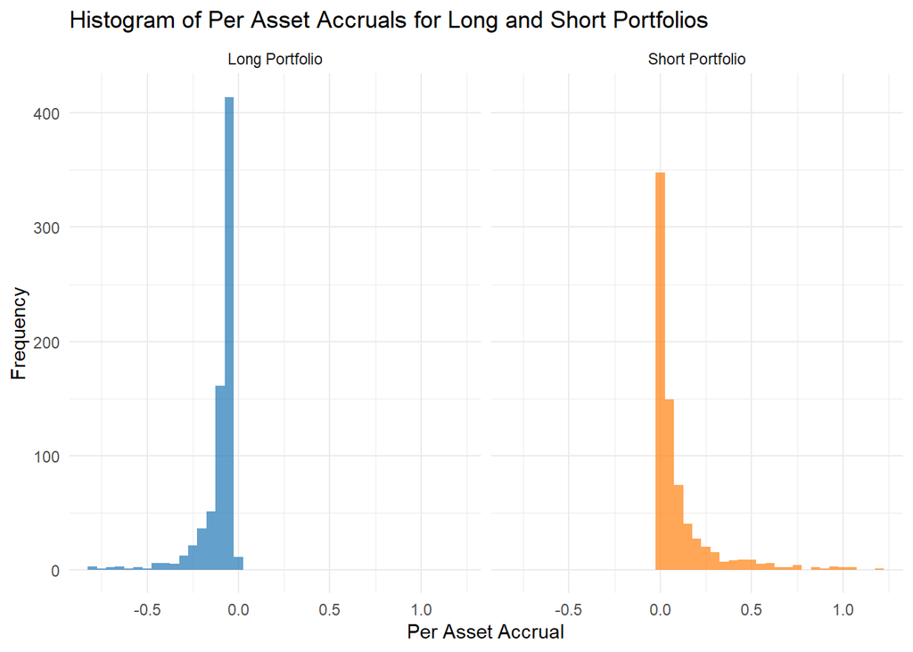

```r
# Add a column to indicate portfolio group
merged_final <- merged_final %>%
  mutate(Portfolio = ifelse(Per_Asset_Accrual_2021 < median(Per_Asset_Accrual_2021), "Long Portfolio", "Short Portfolio"))

# Histogram of Per Asset Accruals for Long and Short portfolios
ggplot(merged_final, aes(x = Per_Asset_Accrual_2021, fill = Portfolio)) +
  geom_histogram(binwidth = 0.05, alpha = 0.7, position = "identity") +
  scale_fill_manual(values = c("Long Portfolio" = "#1f77b4", "Short Portfolio" = "#ff7f0e")) +
  facet_wrap(~ Portfolio) +
  labs(title = "Histogram of Per Asset Accruals for Long and Short Portfolios", x = "Per Asset Accrual", y = "Frequency") +
  theme_minimal() +
  theme(legend.position = "none")
```

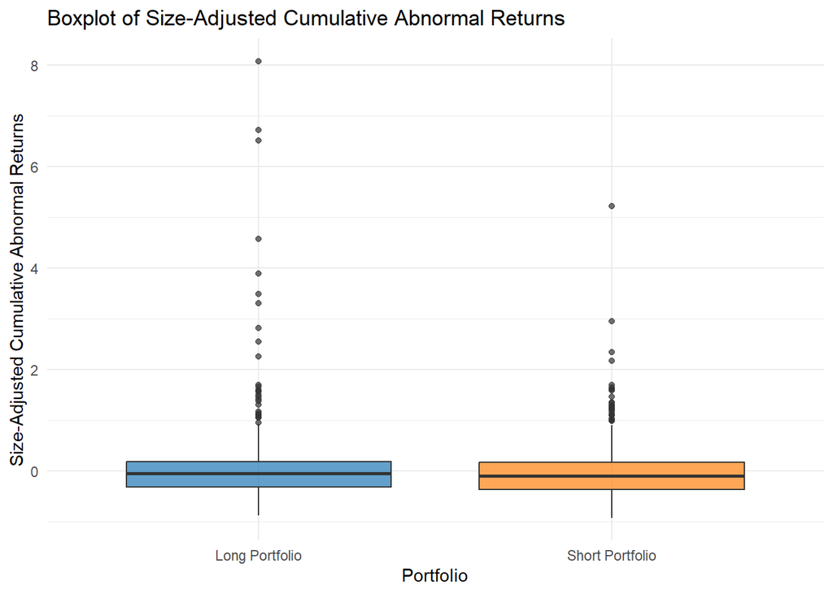

```r
# Boxplot of Size-Adjusted Cumulative Abnormal Returns for Long and Short portfolios
ggplot(merged_final, aes(x = Portfolio, y = Size_Adjusted_Abnormal_Returns, fill = Portfolio)) +
  geom_boxplot(alpha = 0.7) +
  scale_fill_manual(values = c("Long Portfolio" = "#1f77b4", "Short Portfolio" = "#ff7f0e")) +
  labs(title = "Boxplot of Size-Adjusted Cumulative Abnormal Returns", x = "Portfolio", y = "Size-Adjusted Cumulative Abnormal Returns") +
  theme_minimal() +
  theme(legend.position = "none")
```

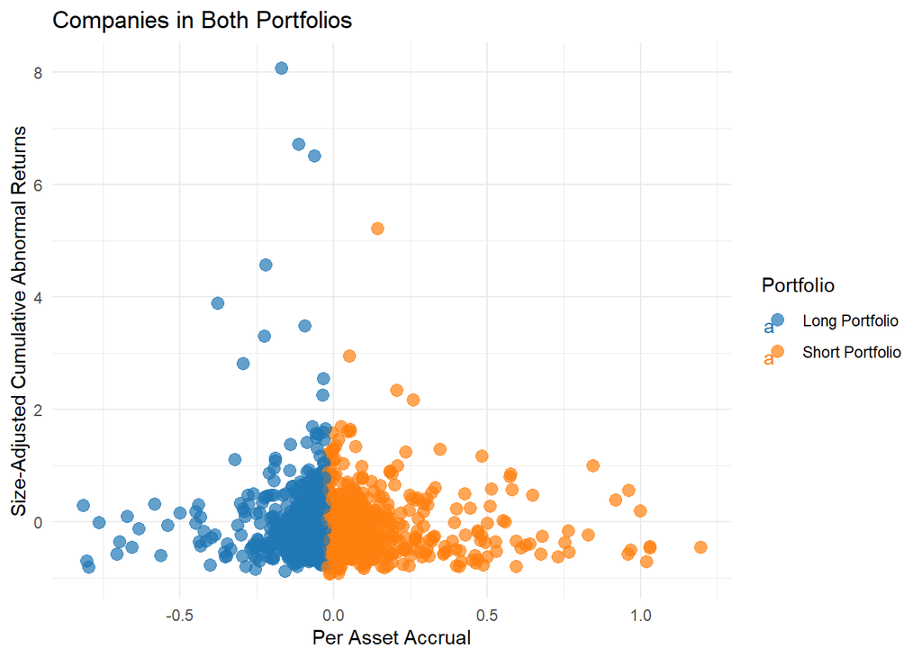

```r
# Scatter plot of Per Asset Accrual vs. Size-Adjusted Cumulative Abnormal Returns for companies in both portfolios
ggplot(merged_final, aes(x = Per_Asset_Accrual_2021, y = Size_Adjusted_Abnormal_Returns, color = Portfolio, label = `Company Name`)) +
  geom_point(alpha = 0.7, size = 3) +
  geom_text(aes(label=ifelse(Portfolio == "Long Portfolio" & Size_Adjusted_Abnormal_Returns > 1, as.character(`Company Name`),'')), hjust=0, vjust=0, check_overlap = TRUE) +
  scale_color_manual(values = c("Long Portfolio" = "#1f77b4", "Short Portfolio" = "#ff7f0e")) +
  labs(title = "Companies in Both Portfolios", x = "Per Asset Accrual", y = "Size-Adjusted Cumulative Abnormal Returns") +
  theme_minimal()
```

```r
library(kableExtra)

# Create a table for the Long Portfolio
long_portfolio_table <- L_group %>%
  select(`Company Name`, `Ticker`, Per_Asset_Accrual_2021, `Size_Adjusted_Abnormal_Returns`) %>%
  arrange(Per_Asset_Accrual_2021)

kable(long_portfolio_table, format = "markdown", caption = "Long Portfolio: Companies with Lowest Per Asset Accrual") %>%
  kable_styling(latex_options = c("striped", "hold_position"), full_width = F)
```

Long Portfolio: Companies with Lowest Per Asset Accrual

| Company Name | Ticker | Per_Asset_Accrual_2021 | Size_Adjusted_Abnormal_Returns |
| --- | --- | --- | --- |
| SPECTRUM PHARMACEUTICALS INC | SPPI | -0.8163297 | 0.2979816 |
| SIYATA MOBILE INC | SYTA | -0.8046241 | -0.6942267 |
| AGILE THERAPEUTICS INC | AGRX | -0.7975088 | -0.7982572 |
| EMERSON RADIO CORP | MSN | -0.7633621 | -0.0115275 |
| EXICURE INC | XCUR | -0.7063613 | -0.5640285 |
| ATRECA INC | BCEL | -0.6980626 | -0.3543373 |
| MALACCA STRAITS ACQ CO LTD | MLAC | -0.6716796 | 0.1064311 |
| DATASEA INC | DTSS | -0.6569028 | -0.4405528 |
| ALLOVIR INC | ALVR | -0.6338401 | -0.1190435 |
| BLUEBIRD BIO INC | BLUE | -0.5839026 | 0.3232583 |
| WORKHORSE GROUP INC | WKHS | -0.5623617 | -0.5917117 |
| GENERATION BIO CO | GBIO | -0.5404332 | -0.0589034 |
| ELECTROCORE INC | ECOR | -0.5006792 | 0.1611900 |
| GEOVAX LABS INC | GOVX | -0.4500924 | -0.0144665 |
| VOYAGER THERAPEUTICS INC | VYGR | -0.4482313 | 0.1935787 |
| SILK ROAD MEDICAL INC | SILK | -0.4404431 | 0.3086590 |
| KALA BIO INC | KALA | -0.4369462 | -0.3449764 |
| CORCEPT THERAPEUTICS INC | CORT | -0.4331448 | 0.0866449 |
| ITEOS THERAPEUTICS INC | ITOS | -0.4327788 | -0.4255481 |
| CIBUS INC | CBUS | -0.4212851 | -0.1659528 |
| COMMUNICATIONS SYSTEMS INC | JCS | -0.4156552 | -0.3399637 |
| POLYPID LTD | PYPD | -0.4031578 | -0.7679706 |
| NOVA LIFESTYLE INC | NVFY | -0.3970319 | -0.2782562 |
| KARYOPHARM THERAPEUTICS INC | KPTI | -0.3860921 | -0.2218698 |
| CYMABAY THERAPEUTICS INC | CBAY | -0.3774383 | 3.8978660 |

```r
# Create a table for the Short Portfolio
short_portfolio_table <- H_group %>%
  select(`Company Name`, `Ticker`, Per_Asset_Accrual_2021, `Size_Adjusted_Abnormal_Returns`) %>%
  arrange(desc(Per_Asset_Accrual_2021))

kable(short_portfolio_table, format = "markdown", caption = "Short Portfolio: Companies with Highest Per Asset Accrual") %>%
  kable_styling(latex_options = c("striped", "hold_position"), full_width = F)
```

Short Portfolio: Companies with Highest Per Asset Accrual

| Company Name | Ticker | Per_Asset_Accrual_2021 | Size_Adjusted_Abnormal_Returns |
| --- | --- | --- | --- |
| ATYR PHARMA INC | LIFE | 1.1947000 | -0.4403999 |
| RED CAT HOLDINGS INC | RCAT | 1.0293680 | -0.4285803 |
| BIONANO GENOMICS INC | BNGO | 1.0290801 | -0.4530626 |
| FREIGHT TECHNOLOGIES INC | FRGT | 1.0179584 | -0.6986785 |
| BRILLIANT ACQUISITION CORP | BRLI | 0.9988877 | 0.2027016 |
| ARVINAS INC | ARVN | 0.9675789 | -0.4945299 |
| PRELUDE THERAPEUTICS INC | PRLD | 0.9600596 | 0.5712507 |
| LIPOCINE INC | LPCN | 0.9574613 | -0.5697229 |
| CARDIFF ONCOLOGY INC | CRDF | 0.9189048 | 0.3893586 |
| OLEMA PHARMACEUTICALS INC | OLMA | 0.8445935 | 1.0054104 |
| ACLARIS THERAPEUTICS INC | ACRS | 0.8286526 | -0.2214482 |
| KARTOON STUDIOS INC | TOON | 0.7655863 | -0.5278169 |
| ASTROTECH CORP | ASTC | 0.7634951 | -0.1550311 |
| INSPIREMD INC | NSPR | 0.7519004 | -0.3637906 |
| FULCRUM THERAPEUTICS INC | FULC | 0.7302819 | -0.6152121 |
| URANIUM ROYALTY CORP | UROY | 0.6784900 | -0.2515849 |
| GEVO INC | GEVO | 0.6756449 | -0.5624186 |
| XENON PHARMACEUTICALS INC | XENE | 0.6475388 | 0.4775684 |
| OCEAN POWER TECHNOLOGIES INC | OPTT | 0.6380547 | -0.3852015 |
| ENLIVEX THERAPEUTICS LTD | ENLV | 0.6245424 | -0.4058380 |
| EVOKE PHARMA INC | EVOK | 0.6097866 | -0.4644639 |
| FARMMI INC | FAMI | 0.5947645 | -0.7823975 |
| FOGHORN THERAPEUTICS INC | FHTX | 0.5944893 | -0.3395985 |
| IMMERSION CORP | IMMR | 0.5799521 | 0.5759905 |
| CELSIUS HOLDINGS INC | CELH | 0.5768457 | 0.8534504 |

## Conclusion

The analysis aimed to investigate the earnings quality signal by calculating the accrual component of operating income and constructing a long/short portfolio based on this metric. The descriptive statistics provided insights into the financial characteristics and performance of the sampled firms, while the performance of the portfolios gave a clearer picture of the strategy’s effectiveness.

### Key Findings:

1. **Per Asset Accrual and Portfolio Formation:**
   - **Long Portfolio (L group):** Consisted of firms with the lowest Per Asset Accrual, averaging -0.5511. The average Size-Adjusted Cumulative Abnormal Return was -0.0326.
   - **Short Portfolio (H group):** Comprised of firms with the highest Per Asset Accrual, averaging 0.7991. The average Size-Adjusted Cumulative Abnormal Return was -0.1634.
   - **Hedge Return:** Calculated as the difference between the average Size-Adjusted Cumulative Abnormal Returns of the L and H groups, yielding a positive hedge return of 0.1307.
2. **Descriptive Statistics:**
   - The sample included a wide range of Per Asset Accrual values, from -0.8163 to 1.1947, with a mean of -0.0021.
   - Operating Income and Cash Flow metrics also exhibited significant variability, indicating diverse financial performance across firms.

### Portfolio Companies:

- **Long Portfolio (L group):** Includes companies like Spectrum Pharmaceuticals Inc (SPPI), Siyata Mobile Inc (SYTA), and Agile Therapeutics Inc (AGRX).
- **Short Portfolio (H group):** Includes companies like Celsius Holdings Inc (CELH), Immersion Corp (IMMR), and Foghorn Therapeutics Inc (FHTX).

### Interpretation:

- **Performance of Long Portfolio (L group):** The firms with the lowest accruals, while expected to perform better due to high earnings quality, yielded an average negative Size-Adjusted Cumulative Abnormal Return of -0.0326.
- **Performance of Short Portfolio (H group):** Firms with the highest accruals, typically seen as having lower earnings quality, also had negative returns but significantly lower at -0.1634.
- **Hedge Return:** A positive hedge return of 0.1307 indicates that a strategy of going long on the L group and short on the H group could yield positive returns despite both groups having negative average returns individually.

### Limitations and Future Research:

- The presence of outliers and extreme values in both groups highlights the need for robust statistical methods to handle such anomalies.
- Missing values and data quality issues should be addressed to improve the accuracy of the analysis.
- Expanding the dataset and incorporating more firms across different sectors could provide more generalized insights.
- Further research could involve exploring other financial indicators or a multi-factor model to enhance the predictive power of the investment strategy.

Overall, this project demonstrates the application of financial analytics in constructing investment strategies and provides valuable insights into the relationship between accruals and stock performance.